# Nüfus ve Sosyal Araştırmalar Enstitüsü - Yapay Zeka Modülü : Makine Öğrenmesi - 1

Zeka, bir adaptasyon yeteneği. Değişen şartlara adapte olma yeteneğidir. *Dr. Oktay Altun*

## 1 - Yapay Zekanın Tarihsel Gelişimi Zaman Çizelgesi

[figure not shown]

### 1.1 Temel Atma ve Doğuş (1900 - 1973)

Yapay zekanın henüz bir fikir olduğu, bilgisayar biliminin temellerinin atıldığı dönemdir.

- **1900-1950:** Vakum tüplerinin icadı, dijital mantık ve sibernetik kavramlarının ortaya çıkışı bu döneme rastlar.
- **1950 - Turing Testi:** Alan Turing, makinelerin düşünebilip düşünemeyeceğini sorgular. Benzer şekilde Cahit Arf'da bunu düşünmüştür.
- **1956 - "Yapay Zeka" Teriminin Doğuşu:** John McCarthy tarafından Dartmouth Konferansı'nda bu terim ilk kez kullanılmıştır.
- **1965:** İlk sohbet botu (ChatBot) olan **Eliza** geliştirildi.

> **Kısa Hikaye: Turing'in Oyunu** 1950 yılında İngiliz matematikçi Alan Turing, "Makineler düşünebilir mi?" sorusunu sormak yerine pratik bir test önerdi: Bir insan, bir klavye aracılığıyla biri insan diğeri makine olan iki farklı varlıkla sohbet eder. Eğer hangi taraftakinin makine olduğunu anlayamazsa, o makine "Turing Testi"ni geçmiş ve zeki kabul edilmiş sayılır. Bu test, günümüz yapay zeka felsefesinin hala temel taşlarından biridir.

### 1.2 Yapay Zeka Kışları ve Algoritmik Gelişmeler (1973 - 2000)

Bu dönem, büyük umutların hayal kırıklığına dönüştüğü durgunluk dönemlerini (Yapay Zeka Kışları) ve sonrasındaki algoritmik sıçramaları içerir.

- **1. Kış (1973-1980) ve 2. Kış (1987-1993):** Fonların kesildiği, yapay zekaya olan inancın azaldığı dönemlerdir.
- **1986 - Geri Yayılım (Backpropagation):** Çok katmanlı sinir ağlarının öğrenmesini sağlayan ve bugünkü yapay zekanın temelini oluşturan devrimsel bir adımdır.
- **1997 - Deep Blue:** IBM'in satranç bilgisayarı.

> **Kısa Hikaye: Makinenin Şah Matı** 1997 yılında IBM tarafından geliştirilen **Deep Blue** adlı sistem, dönemin yenilmez Dünya Satranç Şampiyonu Garry Kasparov'un karşısına oturdu. Kasparov makineyi küçümsese de, Deep Blue saniyede 200 milyon pozisyonu hesaplayarak şampiyonu mağlup etmeyi başardı. Bu olay, makinelerin insanın analitik zekasını belirli kurallar çerçevesinde aşabileceğinin ilk büyük kanıtı oldu ve tüm dünyada şok etkisi yarattı.

### 1.3 Derin Öğrenme ve Büyük Veri Çağı (2000 - 2017)

İnternetin yaygınlaşması, büyük veri ve güçlü ekran kartlarının (GPU) birleşimiyle yapay zeka altın çağına girdi.

- **2010 - Apple Siri:** Sesli asistanların hayatımıza girişi.
- **2012 - AlexNet:** Görüntü tanıma (ImageNet) yarışmasında diğer tüm algoritmaları ezici bir farkla geçerek derin öğrenme (Deep Learning) devrimini başlattı.
- **2016 - AlphaGo:** Karmaşık Go oyununda dünya şampiyonunu yendi.
- **2017 - Transformers:** Google tarafından yayınlanan "Attention Is All You Need" makalesi, bugünkü ChatGPT gibi sistemlerin temel mimarisini oluşturdu.

> **Kısa Hikaye: Go Tahtasındaki Sezgi** Satrançtan milyonlarca kat daha fazla olasılığa sahip olan, Uzak Doğu'nun kadim oyunu Go'da bir bilgisayarın insanı yenmesi için onlarca yıl gerektiği düşünülüyordu. 2016'da Google DeepMind'ın geliştirdiği **AlphaGo**, efsanevi Go şampiyonu Lee Sedol ile karşılaştı. İkinci maçın 37. hamlesinde AlphaGo, hiçbir insanın yapmayacağı kadar garip ama dahiyane bir hamle yaptı. Bu hamle, makinenin sadece ezberlemediğini, adeta "sezgisel" bir strateji geliştirdiğini gösterdi ve maçı kazandırdı.

### 1.4 Üretken Yapay Zeka (Generative AI) Devrimi (2017 - 2025)

Makinelerin sadece anlamakla kalmayıp, metin, kod ve görsel üretmeye başladığı dönemdir.

- **2020 - DALL-E & GPT-3:** Metin komutlarından yüksek kaliteli görseller ve insan benzeri metinler üretebilen sistemlerin çıkışı.
- **2022 - ChatGPT:** OpenAI'ın piyasaya sürdüğü ChatGPT, sadece 2 ay içinde dünyanın en hızlı büyüyen tüketici yazılımı oldu.
- **2024:** Video üretebilen yapay zeka **Sora** ve Avrupa Birliği'nin yasal çerçevesi olan **EU AI Act** (AB Yapay Zeka Yasası).
- **2025 - DeepSeek:** Görselde, Çinli DeepSeek'in hızlı yükselişiyle OpenAI'ı ciddi şekilde zorladığı (overpasses) belirtiliyor.

## 1.5 Gelecek: 2025 ve Ötesi

Zaman çizelgesinin en sonu, henüz ulaşmadığımız ama bilimkurgudan çıkıp bilimsel bir hedefe dönüşen kavramlara ayrılmış:

- **AGI (Artificial General Intelligence):** Bir insanın yapabileceği her türlü zihinsel görevi başarıyla yerine getirebilen Yapay Genel Zeka.
- **ASI (Artificial Super Intelligence):** İnsan zekasının kapasitesini her alanda fersah fersah aşan Süper Zeka.
- **Tekillik (Singularity) & Süper İnsanlar:** Yapay zekanın kendi kendini geliştirebileceği ve insan evrimini dönüştüreceği öngörülen o kırılma noktası.

## 2 - Yapay Zeka ve Sistem Modelleme Temelleri

### 2.1 Yapay Zeka (AI) Ekosistemi ve Hiyerarşisi

Yapay zeka alanları, kapsayıcılıklarına göre iç içe geçmiş kümeler halinde ifade edilir:

- **Yapay Zeka (AI / YZ):** İnsan zekasını taklit etmeyi amaçlayan en geniş şemsiye kavramdır.
- **Makine Öğrenmesi (ML / MÖ):** Yapay zekanın bir alt dalıdır. Veriyi kullanarak öğrenen ve zamanla kendini geliştiren algoritmaları kapsar.
- **Derin Öğrenme (DL / DÖ):** Makine öğrenmesinin bir alt dalıdır. Çok katmanlı yapay sinir ağlarını kullanarak daha karmaşık verileri (görüntü, ses vb.) işler.

**Hiyerarşi:** AI > ML > DL

#### İstisna: Uzman Sistemler (Expert Systems)

- Uzman sistemler, **Yapay Zeka (AI)** kümesinin içinde yer alır ancak **Makine Öğrenmesi (ML)** kümesine dahil değildir.
- Sebebi: Makine öğrenmesi gibi veriden kendi kendine kural çıkarmazlar. Doğrudan bir alandaki insan uzmanların koyduğu kural setlerini (Eğer-O zaman kuralları) ve kararları taklit ederler.

### 2.2 Sistem Yaklaşımı ve Öğrenme Paradigması

Dünyadaki süreçler genellikle bir "Sistem" olarak modellenebilir. Bu temel yapı şu şekildedir: **Girdi (Input: $x$) -> Sistem Fonksiyonu [$f(x)$] -> Çıktı (Output)**

- **Geleneksel Yaklaşım:** $f(x)$ sistemini (kuralları ve denklemleri) insanlar olarak biz tasarlamaya çalışırız.
- **Makine Öğrenmesi Yaklaşımı:** Artık $f(x)$ sistemini manuel olarak kurmak üzerine kafa yormuyoruz. Bunun yerine bol miktarda girdi verisi ($x$) ve bu girdilere karşılık gelen gerçek çıktıları topluyoruz. Sistemi bu verilerle besleyerek makinenin aradaki $f(x)$ kuralını **tahmin etmesini (öğrenmesini)** sağlıyoruz.

### 2.3 Sistem Örnekleri

#### Örnek A: Ekonomi Bir Sistemdir

Ekonomiyi karmaşık bir fonksiyon $f(x)$ olarak düşündüğümüzde:

**Girdiler ($x$):**

- `labor` (Emek / İş gücü)
- `M` (Para Arzı)
- `r` (Politika Faizi)

**Çıktılar (Output):**

- `GDP` (Gayrisafi Yurt İçi Hasıla / Milli Gelir)
- `inflation` (Enflasyon)
- `wealth` (Refah seviyesi)
- `growth` (Ekonomik büyüme)

Makine öğrenmesi modelleri, geçmişteki faiz, para arzı ve emek verilerine bakarak gelecekteki enflasyon veya büyüme rakamlarını tahmin eden bir $f(x)$ fonksiyonu oluşturabilir.

#### Örnek B: Medikal Görüntüleme Sistemi

Görüntü işleme görevlerinde girdiler ve çıktılar vektörler/matrisler halinde ifade edilir.

- **Girdi ($x$):** Bir röntgen veya MR görüntüsü (piksellerden oluşan bir matris).
- **Sistem [$f(x)$]:** Medikal görüntüyü analiz eden Derin Öğrenme (DL) modeli.
- **Çıktı:** Görüntüdeki tümörün tespiti, hastalığın sınıflandırılması veya işaretlenmiş yeni bir görüntü (çıktı matrisi).

## 3 - Yapay Sinir Ağları ve Derin Öğrenmenin Matematiksel Temeli

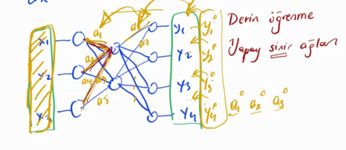

*mavi sarı yeşil sırasıyla çizildi*

### 3.1 Tekil Bir Nöronun (Sinir Hücresinin) Yapısı

- **Girdiler (Inputs):** $x_1, x_2, x_3$
- **Ağırlıklar (Weights):** $a_1, a_2, a_3$ (Bunlar sistemin öğrenerek güncelleyeceği önem dereceleridir).
- **Çıktı (Output):** $y$
- **İşleyiş:** Her bir girdi, kendi ağırlığı ile çarpılır ve toplanır. Sonra bir $f$ (aktivasyon) fonksiyonundan geçirilerek $y$ çıktısı elde edilir.
- **Matematiksel Gösterim:** $$y = f(a_1x_1 + a_2x_2 + a_3x_3)$$

### 3.3 Derin Öğrenme ve Yapay Sinir Ağları (YSA)

Tahtanın alt kısmında "Derin Öğrenme" (Deep Learning) ve "Yapay Sinir Ağları" başlıkları altında çok katmanlı bir ağ mimarisi çizilmiştir.

- **Girdi Katmanı (Input Layer):** Sol taraftaki $x_1, x_2, x_3$ vektörü.
- **Gizli Katmanlar (Hidden Layers):** Ortadaki yuvarlak düğümler. Bu düğümler birbirlerine $a_1, a_2, a_3, a_4, a_5$ gibi çeşitli ağırlık bağlarıyla bağlıdır.
- **Çıktı Katmanı (Output Layer):** Sağ taraftaki $y_1, y_2, y_3, y_4$ vektörü.
- **Ağ Yapısı:** Kırmızı ve mavi çizgilerle gösterildiği üzere, bir düğümden çıkan bilgi sonraki katmandaki birden fazla düğüme dağılır. Sistem, milyarlarca parametreden oluşan bu karmaşık ağ yapısı ve Geri Yayılım algoritması sayesinde, en karmaşık $f(x)$ fonksiyonlarını bile tahmin edebilir hale gelir.

### 3.4 Ağın Öğrenme Süreci (Görselleştirilmiş Geri Yayılım)

Tahtaya sonradan eklenen sarı çizimler ve oklar, yapay sinir ağının veriden kural çıkarma (öğrenme) sürecinin adımlarını göstermektedir:

### 3.4.1 İleri Besleme (Forward Pass)

- **Sarı Taralı Girdi ($x$):** Eğitim verisi sisteme verilir.
- Veri, ağdaki mevcut (başlangıçta rastgele olan) ağırlıklar ($a_1, a_2$ vb.) ile çarpılıp toplanarak sağ tarafa kadar ilerler ve sistem bir tahminde bulunur.
- Bu tahmin edilen çıktı **$y$** vektörüdür ($y_1, y_2, y_3, y_4$).

### 3.4.2 Hata Hesaplama ($y$ vs $y^D$)

- **Sarı $y^D$ Vektörü:** Sağ tarafa sonradan eklenen $y^D$ (Desired Output / Hedeflenen Çıktı), verinin **gerçek/doğru** değeridir (Ground Truth).
- Sistem, kendi tahmini olan **$y$** ile olması gereken gerçek değer olan **$y^D$**'yi karşılaştırır. Aradaki fark **"Hata" (Loss/Error)** olarak hesaplanır.

### 3.4.3 Geri Yayılım ve Ağırlık Güncelleme (Sarı Oklar)

**Özetle:** Veri girer $\rightarrow$ Tahmin yapılır ($y$) $\rightarrow$ Gerçekle karşılaştırılıp hata bulunur ($y^D$) $\rightarrow$ Hata geriye yayılarak (Sarı oklar) ağırlıklar ($a$) düzeltilir. Bu döngü binlerce kez tekrarlanarak sistemin $f(x)$ fonksiyonunu öğrenmesi sağlanır.

### 3.5 Ağın Mimarisi ve Katman Yapısı (Yeşil Çizimler)

Görsele sonradan eklenen yeşil çizimler ve isimlendirmeler, Yapay Sinir Ağının (YSA) yapısal mimarisini detaylandırmaktadır:

- **Nöron (Neuron):** Ağdaki her bir yuvarlak düğüme (node) "nöron" adı verilir. İnsan beynindeki sinir hücrelerinden ilham alan bu yapılar; bilgiyi alır, işler (matematiksel bir fonksiyondan geçirir) ve bir sonraki aşamaya aktarır.
- **Bağlantı (Connection):** Nöronları birbirine bağlayan ve verinin aktığı çizgilere denir. Her bağlantının, sistemin öğrenme aşamasında güncellediği bir "ağırlık" (weight - $a_1, a_2$ vb.) değeri vardır.
- **Katmanlar (Layers):** Nöronların dikey olarak gruplandığı her bir sütuna "katman" denir. Yeşil kesik çizgilerle ağın aşamaları şu şekilde ayrılmıştır:
  - **1. Katman (1. Layer):** Verinin ($x_1, x_2, x_3$) ağa girdiği ilk kısımdır (Girdi Katmanı / Input Layer).
  - **2. Katman ve 3. Katman:** Ağa giren verinin işlendiği, matematiksel dönüşümlerin yapıldığı "Gizli Katmanlar"dır (Hidden Layers). Son katman ise genellikle tahmini veren "Çıktı Katmanı" (Output Layer) ile birleşir.
- **"Derin" Öğrenmenin Anlamı (4-5-6 Notu):** Tahtanın sağ alt köşesinde yeşil renkle yazılan "4 - 5 - 6" sayıları kritik bir noktayı temsil eder. Geleneksel yapay sinir ağlarında genellikle 1 veya 2 gizli katman bulunur. Ancak bu katmanların sayısı 4, 5, 6, 10 veya 100 gibi çok yüksek sayılara çıktığında, kurulan bu devasa ve çok katmanlı yapıya **"Derin Öğrenme" (Deep Learning)** adı verilir. Yani "derin" kelimesi, ağdaki katman sayısının (mimari derinliğin) fazlalığını ifade eder.

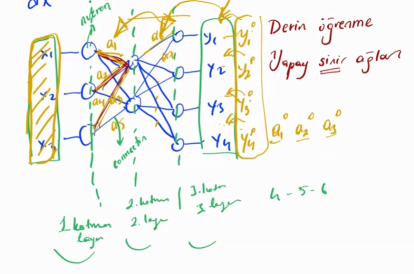

### 3.6 Derinlik Kavramı ve Öğrenmenin Doğası

Görsele eklenen son kısımlar, ağın derinliği ve modelin veriden öğrenme kalitesiyle (başarısıyla) ilgili çok önemli iki temel kavramı açıklamaktadır:

#### Öğrenme (Learning): Genelleme vs. Ezberleme

Makine öğrenmesinde sistemin veriyi "Öğrenme" (Learning) süreci iki farklı şekilde sonuçlanabilir. Tahtada bu durum ikiye ayrılmıştır:

- **Genelleme (Generalization):** Makine öğrenmesinde ulaşmak istediğimiz asıl hedeftir. Modelin eğitim verisindeki ana kuralı, mantığı ve örüntüyü (yani aradığımız $f(x)$ fonksiyonunu) gerçekten kavramasıdır. İyi genelleyen bir model, daha önce **hiç görmediği yeni verilerle** karşılaştığında da başarılı ve doğru tahminler yapabilir.
- **Ezberleme (Memorization / Overfitting):** Kaçınmaya çalıştığımız istenmeyen durumdur (literatürde aşırı öğrenme/overfitting olarak da bilinir). Modelin verinin içindeki mantığı anlamak yerine, sadece ona verilen eğitim verisindeki örnekleri ezberlemesidir. Tıpkı matematiği anlamayıp sadece kitaptaki örnek soruların cevaplarını ezberleyen bir öğrenci gibi, eğitim aşamasında kusursuz sonuç verir ama karşısına **yeni/farklı bir veri (soru)** geldiğinde çuvallar.

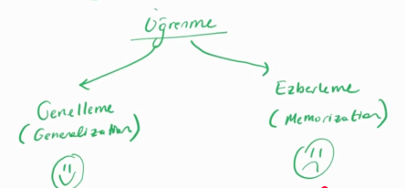

## 4 - Düşünce (Zeka) Kavramının Bileşenleri

Yapay zekanın (AI) tam olarak neyi taklit etmeye çalıştığını anlamak için, insan zekasının merkezinde yer alan "Düşünce" kavramının alt bileşenlerini incelemek gerekir. Görseldeki şema, düşünceyi iki temel kategoriye ayırmaktadır:

### A. Bilişsel ve İşlemsel Yetenekler (Mavi Kısım)

Bu modüller, insan düşüncesinin mantıksal, analitik ve hesaplanabilir süreçlerini kapsar. Günümüz Yapay Zeka ve Makine Öğrenmesi sistemlerinin odaklandığı, modelleyebildiği ve hatta bazılarında insanı geçebildiği alanlardır:

- **Karar Verme:** Belirli parametrelere (girdilere) bakarak en uygun seçeneği belirleme.
- **Planlama:** Bir hedefe ulaşmak için adımları algoritmik olarak organize etme.
- **Problem Çözme:** Bir engeli aşmak için veriyi kullanma ve matematiksel çözümler üretme.
- **Adapte Olma:** Değişen verilere ve çevresel şartlara göre sistemin kendini güncellemesi (Makine öğrenmesindeki "öğrenme" süreci).
- **Çıkarsama:** Mevcut bilgilerden (eğitim verisinden) yola çıkarak bilinmeyen durumlar (yeni veriler) hakkında tahminde bulunma.

### B. Soyut ve İnsani Nitelikler (Turuncu Kısım)

Bu kavramlar, biyolojik varlığımıza, psikolojimize ve felsefi yapımıza ait niteliklerdir. Günümüzdeki en gelişmiş Derin Öğrenme modellerinde bile **bulunmayan** ve salt veriden/matematikten üretilmesi şu an için mümkün olmayan özelliklerdir:

- **Duygu:** Olaylara karşı psikolojik reaksiyon gösterebilme.
- **Vicdan:** İçsel bir doğru/yanlış tartım mekanizması.
- **Bilinç:** Kendi varlığının, durumunun ve evrenin farkında olma hali (Öz-farkındalık).
- **Ahlak:** Evrensel veya toplumsal "iyi ve kötü" değer yargılarına sahip olma.

**Özetle:** Yapay zeka, şemadaki "mavi" bilişsel yetenekleri matematiksel fonksiyonlar ($f(x)$) ve yapay sinir ağları aracılığıyla son derece başarılı bir şekilde taklit etmektedir. Ancak "turuncu" kısımdaki bilinç, ahlak ve duygu gibi insani niteliklerden tamamen yoksundur.

## 4.1 Terminoloji ve Gerçeklik: "Yapay Zeka" İddialı Bir Kavram mı?

Tüm bu teknik şemaların ve bilişsel ayrımların bize gösterdiği çok net bir gerçek var: **Günümüzde "Yapay Zeka" (AI) olarak adlandırdığımız kavram, şu an fiilen yapılan işe "iki gömlek büyük" gelmektedir.** Bu eleştirel yaklaşımın temel dayanakları şunlardır:

- **İsimlendirme Yanılgısı (İstatistik vs. Zeka):** Piyasada "Yapay Zeka" olarak sunulan sistemlerin neredeyse tamamı, aslında sadece Makine Öğrenmesi (ML) ve Derin Öğrenme (DL) algoritmalarıdır. Yani ortada gerçekten "düşünen" bir zeka değil; devasa veriler içindeki korelasyonları bulan, **olasılıkları** hesaplayan, özünde **nümerik analize ve istatistiksel çıkarsamalara** dayanan çok gelişmiş bir $f(x)$ tahmin modeli vardır.
- **Dar Yapay Zeka (Narrow AI) Gerçeği:** Günümüz sistemleri sadece eğitildikleri spesifik alanda (örneğin sadece satranç oynamak, metin üretmek veya medikal görüntü sınıflandırmak) başarılıdırlar. İnsan zekasının sahip olduğu o "genel" ve esnek kapasiteden (AGI - Yapay Genel Zeka) oldukça uzaktırlar.
- **Anlamanın Yokluğu:** Model, ne yaptığının veya hangi veriyi işlediğinin "farkında" değildir. Bir metin üretirken kelimelerin anlamını bilmez, sadece büyük bir örneklem (sampling) havuzundan yola çıkarak bir sonraki kelimenin gelme olasılığını hesaplar.

**Özetle:** "Yapay Zeka" terimi vizyoner ve cazip bir isimlendirme olsa da, mühendislik ve bilimsel gerçeklik açısından şu an elimizde olan şey "Bilinçli Varlıklar" değil, "Son Derece Başarılı İstatistiksel Tahmin Motorları"dır.

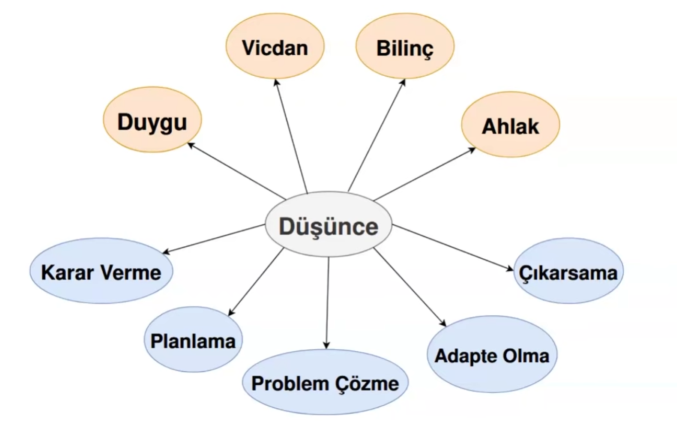

-Memreu